# Accel‑Align: a fast sequence mapper and aligner based on the seed–embed–extend method

Presented by Brian Palmer

## Background

### What is an alignment?

A procecss where we take each *read* and figuring out where it fits in a *reference genome*

*Read* - a sequence of base pairs that *should* correspond to a DNA fragment.

*Reference Genome* - the target sequence of base pairs that we would like to compare our DNA fragment with.

Abstractly, this is a **string matching** problem.

### Okay, so it should be as easy as this:

```python
def find_substring(read, ref_genome):
    '''
    Return the position of the read in the genome
    with this naive approach.

    NOTE: position is zero-based
    '''

    bound_check = 0
    for position, genome_basepair in enumerate(ref_genome):
        if genome_basepair == read[bound_check]:
            bound_check += 1
        else: bound_check = 0

        if bound_check == len(read):
            return position - len(read) + 1

    return -1
```

```python
ref = 'GATACA'
read = 'CAT'

print(find_substring(read, ref))
```

```
-1
```

```python
ref = 'GATACA'
read = 'TAC'

print(find_substring(read, ref))
```

```
2
```

```python
ref = 'GATACA'
read = 'TAC'
print(find_substring(read, ref))
```

```
2
```

### What might be wrong here?

Does not take into account:

1. Differences between the read and the reference genome
2. Sequencing errors

Therefore, we cannot rely on **exact** matches. We need to account for differences and errors.

### Popular string matching distance algorithms

#### Levenshtein Distance

```python
help(levenshtein_distance)

# TODO: Update this with your own strings!
levenshtein_distance('CTGA', 'TGA')
```

```
Help on function levenshtein_distance in module __main__:

levenshtein_distance(read, ref_genome_fragment, print_matrix=True)
    Brief:

    A gapped aligner that counts the differences between two strings
    allowing insertions and deletions.

    Useful comparing string with INDEL errors and substitutions.

    Adapted from rf. https://en.wikipedia.org/wiki/Levenshtein_distance

rows: CTGA
columns: TGA
[[0. 1. 2. 3.]
 [1. 1. 2. 3.]
 [2. 1. 2. 3.]
 [3. 2. 1. 2.]
 [4. 3. 2. 1.]]
```

```
1.0
```

```python
levenshtein_distance('kitten', 'sitting') # from the wikipedia example
```

```
rows: kitten
columns: sitting
[[0. 1. 2. 3. 4. 5. 6. 7.]
 [1. 1. 2. 3. 4. 5. 6. 7.]
 [2. 2. 1. 2. 3. 4. 5. 6.]
 [3. 3. 2. 1. 2. 3. 4. 5.]
 [4. 4. 3. 2. 1. 2. 3. 4.]
 [5. 5. 4. 3. 2. 2. 3. 4.]
 [6. 6. 5. 4. 3. 3. 2. 3.]]
```

```
3.0
```

#### Hamming Distance

```python
def hamming_distance(read, ref_genome):
    '''
    Find the number of differences between two strings.

    TODO: try to implement if you like!
    '''

    raise NotImplementedError('Comment this out!')


# example from rf. https://en.wikipedia.org/wiki/Hamming_distance

read = 'kitten'
ref_genome = 'sitting'

# Uncomment lines below to run

# result = hamming_distance(read, ref_genome)
# print(result)

# assert(result == 2)
```

### Issues current aligners face

Edit distance algorithms such as Levenstein are expensive computationally.

- The comparison in the example above is *O(mn)* and that was using a small fraction of the genome!

The amount of data is continuing to grow.

Additional complexity is added with gap penalty or soft clippings.

### Seed-filter-extend (SFE) strategy

1. Indexing the genome
2. Reads are fragmented into *seeds* that are cross referenced with the indexed genome
3. Candidates are filtered to reduce the computational load of extension.
4. Reads are edit distance approximated using aforementioned string matching algorithms.

### Improvements on Filtering

1. Selection based a. Voting
2. Elimination based a. Adjacency Filtering b. Shifted Hamming Distance

Elimination based filter tend to be more stringent.

- This can lead to over filtering an missalignment.
- Possibly better accuracy, worse performance than selection based methods.

Selection based filters tend to be less stringent.

- They also are faster!

### Their Solution

**Seed-Embed-Extend (SEE) Alignment**

Use recent advancements in *randomized algorithms* to update the filtering step.

Embed read into genome candidate fragments and rank by hamming distance before continuing to extension step.

They show with their tool, *Accel-Align*, implementations that reduce bottlenecks.

## Results

### Simulation

The authors use [Mason2](https://www.seqan.de/apps/mason.html) to generate simulated fastq reads. The [publication](http://publications.imp.fu-berlin.de/962/2/mason201009.pdf) provides a succinct introduction to their tool.

```
wget http://packages.seqan.de/mason2/mason2-2.0.9-Linux-x86_64.tar.xz
unxz mason2-2.0.9-Linux-x86_64.tar.xz
tar -xvf mason2-2.0.9-Linux-x86_64.tar
cd mason2-2.0.9-Linux-x86_64/bin
./mason_genome --help
```

M. Holtgrewe, “Mason – A Read Simulator for Second Generation Sequencing Data”, 2010-10

```
mason_genome - Random Genome Simulation
=======================================

SYNOPSIS
    mason_genome [OPTIONS] [-l LEN]+ -o OUT.fa

DESCRIPTION
    Simulate a random genome to the output file. For each -l/--contig-length
    entry, a contig with the given length will be simulated.

OPTIONS
    -h, --help
          Display the help message.
    --version-check BOOL
          Turn this option off to disable version update notifications of the
          application. One of 1, ON, TRUE, T, YES, 0, OFF, FALSE, F, and NO.
          Default: 1.
    --version
          Display version information.
    -q, --quiet
          Set verbosity to a minimum.
    -v, --verbose
          Enable verbose output.
    -vv, --very-verbose
          Enable very verbose output.

  Simulation Configuration:
    -l, --contig-length List of INTEGER's
          Length of the contig to simulate. Give one -l value for each contig
          to simulate. In range [1..inf].
    -s, --seed INTEGER
          The seed to use for the random number generator. Default: 0.

  Output Options:
    -o, --out-file OUTPUT_FILE
          Output file. Valid filetypes are: .sam[.*], .raw[.*], .frn[.*],
          .fq[.*], .fna[.*], .ffn[.*], .fastq[.*], .fasta[.*], .faa[.*],
          .fa[.*], and .bam, where * is any of the following extensions: gz
          and bgzf for transparent (de)compression.

EXAMPLES
    mason_genome -l 1000 -l 4000 -o genome.fa
          Simulate a genome with two contigs of lengths 1000 and 4000 and
          write it to genome.fa.

VERSION
    Last update: 2018-02-02_13:03:05_+0100
    mason_genome version: 2.0.9 [e165baf]
    SeqAn version: 2.4.0
```

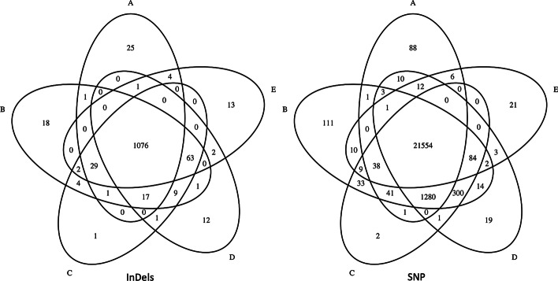